# Homework 4&5 solutions

## Q11

ATQ, there are four campuses in total 15 emergency cases randomly selected from each campus It is a random assignment design Factor: Campus Levels: Main campus, Satellite.1, Satellite.2, Satellite.3 Levels and treatments are same in one factor ANOVA

For mean waiting time: - $H_{0}$ : $\mu_{main}=\mu_{sat1}=\mu_{sat2}=\mu_{sat3}$  
- $H_{a}$ : Atleast one mean is different

```r
q11 <- read.csv('Question11.csv')
head(q11)
```

```
##     Main Satellite.1 Satellite.2 Satellite.3
## 1 120.08       30.75       75.86       54.05
## 2  81.90       61.83       37.88       38.82
## 3  78.79       26.40       68.73       36.85
## 4  63.83       53.84       51.08       32.83
## 5  79.77       72.30       50.21       52.94
## 6  47.94       53.09       58.47       34.13
```

```r
q11 <- stack(q11)
colnames(q11) <- c('w_time','campus')
class(q11$campus)
```

```
## [1] "factor"
```

```r
#Checking normality
#Creating a residual plot
model<- lm(q11$w_time ~ q11$campus)
resids <- residuals(model)
preds<- predict(model)

nortest::ad.test(resids)
```

```
##
##  Anderson-Darling normality test
##
## data:  resids
## A = 0.29114, p-value = 0.5973
```

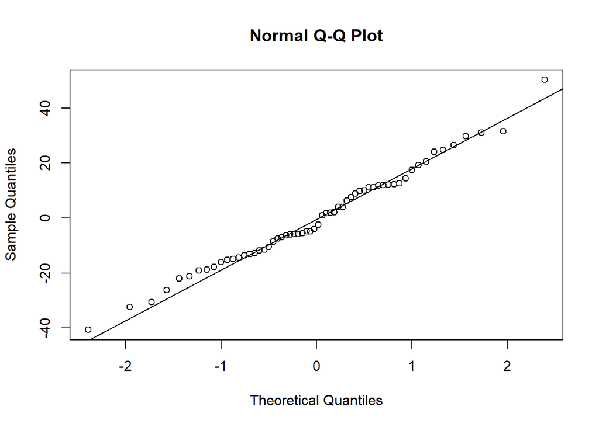

```r
qqnorm(resids)
qqline(resids)
```

```r
#p-value >0.05--> Normality test passed
#All the QQ plot approx. aligns with normal distribution

#Checking for variance
car::leveneTest(q11$w_time ~ q11$campus)
```

```
## Levene's Test for Homogeneity of Variance (center = median)
##       Df F value Pr(>F)
## group  3  0.8201 0.4883
##       56
```

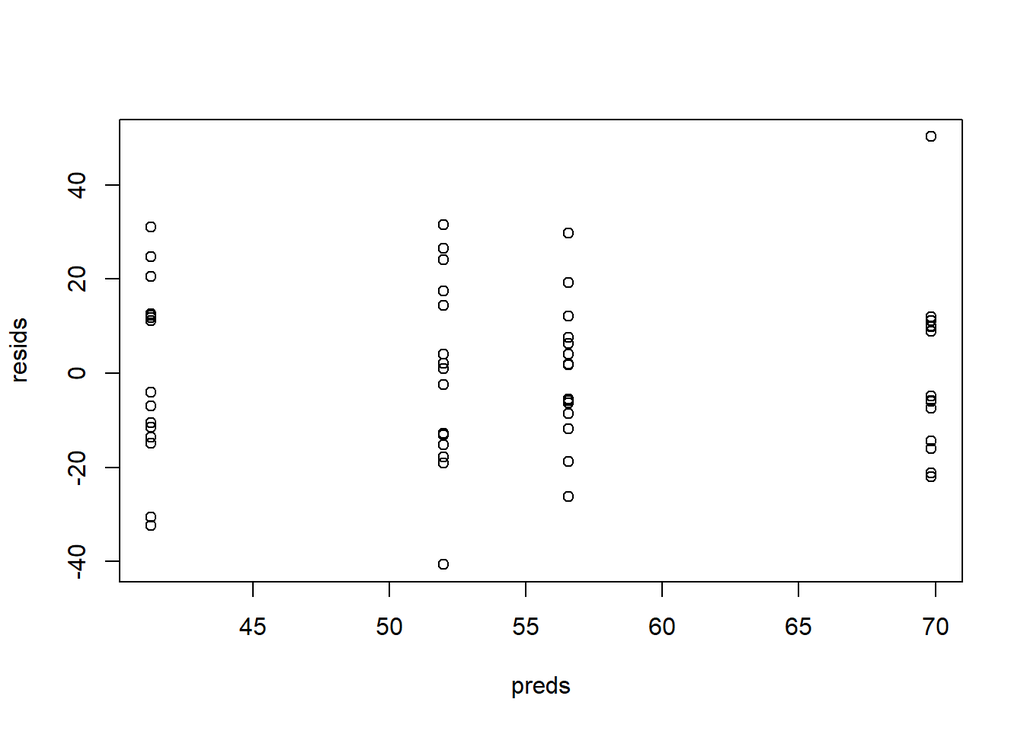

```r
#visual for variance test
plot(preds, resids)
```

```r
#p-value>0.05 -->Constant variance
#and visually it appears somewhat constant variance except few outliers

#Method for one-factor ANOVA
ANOVA_11 <- aov(q11$w_time ~ q11$campus)
summary(ANOVA_11)
```

```
##             Df Sum Sq Mean Sq F value   Pr(>F)
## q11$campus   3   6312  2104.1   6.372 0.000859 ***
## Residuals   56  18493   330.2
## ---
## Signif. codes:  0 '***' 0.001 '**' 0.01 '*' 0.05 '.' 0.1 ' ' 1
```

```r
#Since, p-value <0.05. We reject the null hypothesis
#Proceed with tukey test
TukeyHSD(ANOVA_11)
```

```
##   Tukey multiple comparisons of means
##     95% family-wise confidence level
##
## Fit: aov(formula = q11$w_time ~ q11$campus)
##
## $`q11$campus`
##                               diff        lwr         upr     p adj
## Satellite.1-Main        -28.588667 -46.158986 -11.0183478 0.0003814
## Satellite.2-Main        -13.281333 -30.851652   4.2889855 0.1997139
## Satellite.3-Main        -17.870667 -35.440986  -0.3003478 0.0447878
## Satellite.2-Satellite.1  15.307333  -2.262986  32.8776522 0.1086697
## Satellite.3-Satellite.1  10.718000  -6.852319  28.2883188 0.3785196
## Satellite.3-Satellite.2  -4.589333 -22.159652  12.9809855 0.8998737
```

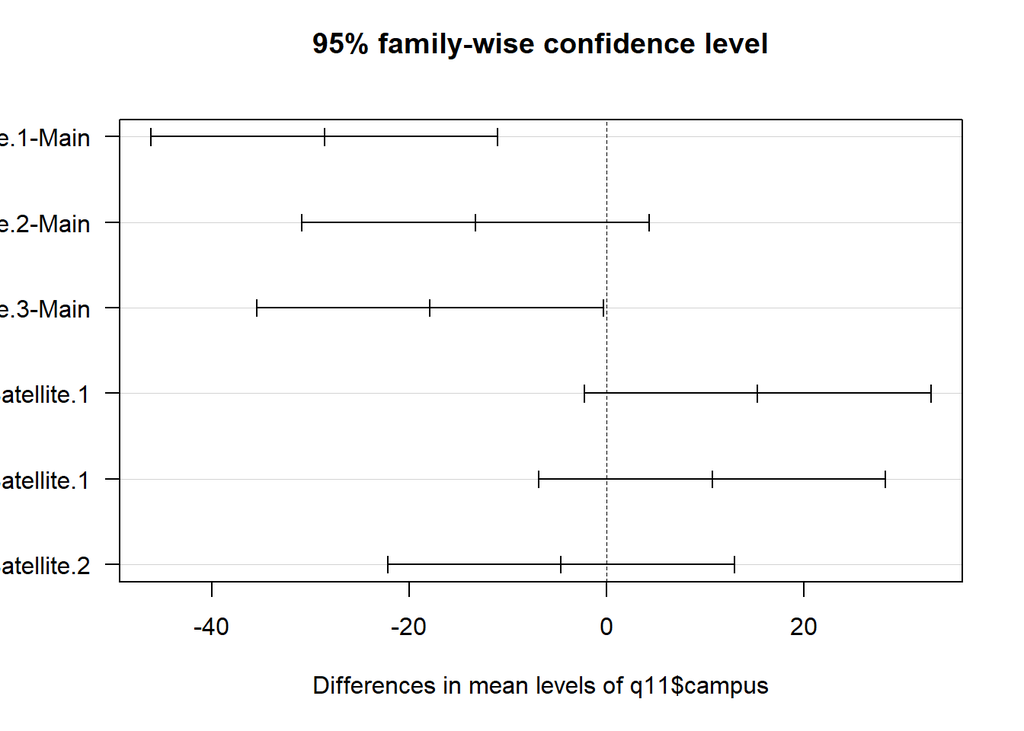

```r
plot(TukeyHSD(ANOVA_11), las = 1)
```

As p-value<0.05 (and any other relevant significance level) => Reject the $H_{0}$ At 5% significance level, there is sufficient evidence to support the claim that there is a difference between the mean waiting times of campuses To determine which population means significantly differ, we used Tukey test p-value for two combination of campuses <0.05 -> Null hypothesis for the two pairs rejected At 5% significance level, there is sufficient evidence to support the claim that mean waiting times of Satellite 1 and main campus are different mean waiting times of Satellite 3 and main campus are different

## Q12

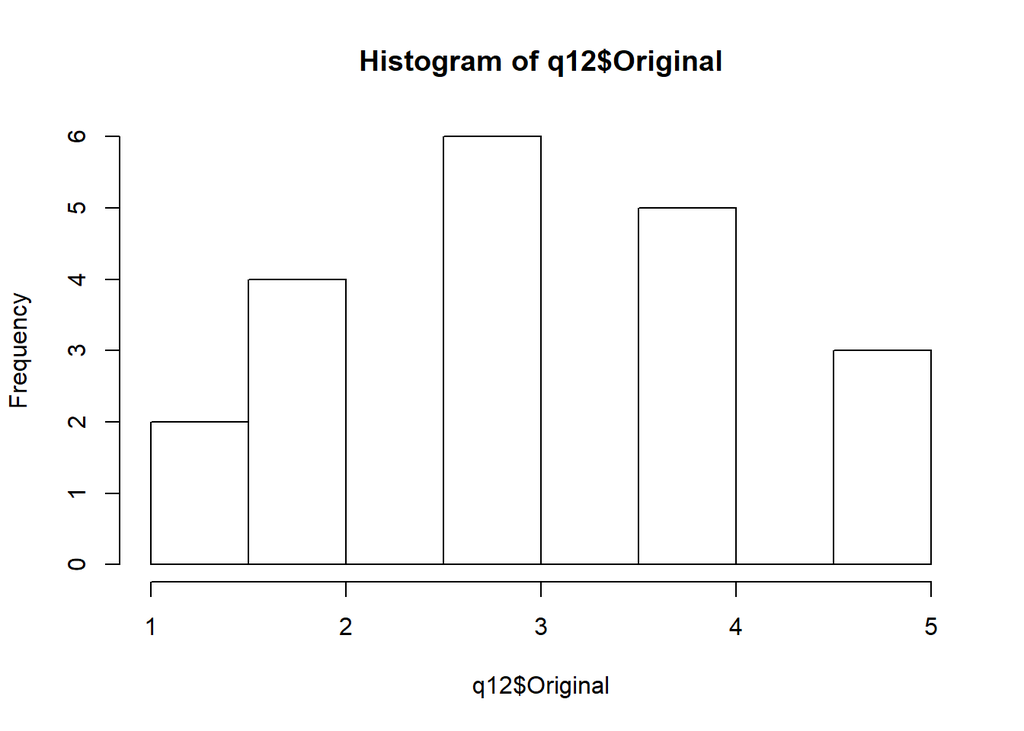

```r
q12 <- read.csv('Question12.csv')
#head(q12)
hist(q12$Original)
```

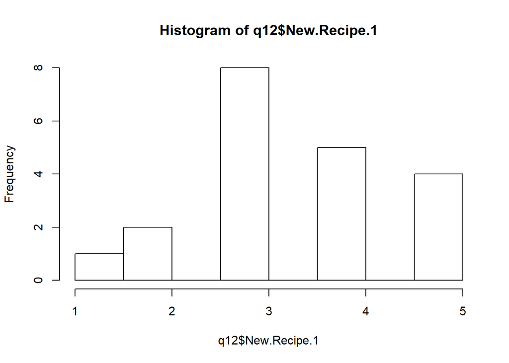

```r
hist(q12$New.Recipe.1)
```

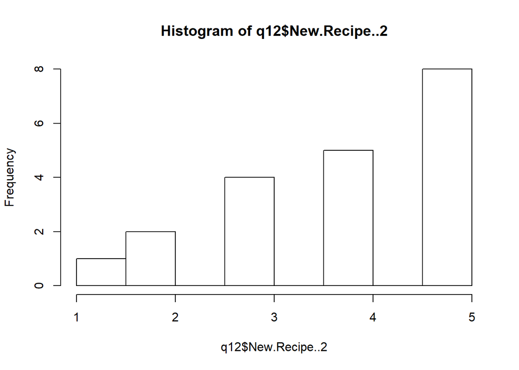

```r
hist(q12$New.Recipe..2)
```

We notice that 2 out of the 3 populations clearly don’t align to norma distribution Since, the condition for normality is failed and our dataset has ordinal values We will try non-parametric test to solve Number of samples-3

Friedman Test - $H_{0}$ : the location of all the three populations is the same - $H_{a}$ : Atleast two population locations differ

```r
#Convert the dataset to stacked format
q12
```

```
##    Person Original New.Recipe.1 New.Recipe..2
## 1       1        5            5             5
## 2       2        3            4             5
## 3       3        4            5             5
## 4       4        2            4             4
## 5       5        3            3             5
## 6       6        2            2             3
## 7       7        3            3             2
## 8       8        4            3             5
## 9       9        1            1             1
## 10     10        1            3             2
## 11     11        2            4             3
## 12     12        3            3             4
## 13     13        5            3             4
## 14     14        3            2             3
## 15     15        4            3             5
## 16     16        4            4             4
## 17     17        2            4             3
## 18     18        5            3             5
## 19     19        4            5             5
## 20     20        3            5             4
```

```r
q12_stacked <- cbind(q12[,1:2],'Original')
q12_stacked
```

```
##    Person Original "Original"
## 1       1        5   Original
## 2       2        3   Original
## 3       3        4   Original
## 4       4        2   Original
## 5       5        3   Original
## 6       6        2   Original
## 7       7        3   Original
## 8       8        4   Original
## 9       9        1   Original
## 10     10        1   Original
## 11     11        2   Original
## 12     12        3   Original
## 13     13        5   Original
## 14     14        3   Original
## 15     15        4   Original
## 16     16        4   Original
## 17     17        2   Original
## 18     18        5   Original
## 19     19        4   Original
## 20     20        3   Original
```

```r
colnames(q12_stacked) <- c('Person','Rating','Recipe')
q12_stacked_t <- cbind(q12[,c(1,3)],'NewRecipe_1')
colnames(q12_stacked_t) <- c('Person','Rating','Recipe')
q12_stacked <- rbind(q12_stacked,q12_stacked_t)
q12_stacked_t <- cbind(q12[,c(1,4)],'NewRecipe_2')
colnames(q12_stacked_t) <- c('Person','Rating','Recipe')
q12_stacked <- rbind(q12_stacked,q12_stacked_t)
rm(q12_stacked_t)

#Make sure column types are correct
q12_stacked$Person <- factor(q12_stacked$Person)
q12_stacked$Recipe <- factor(q12_stacked$Recipe)

#Run Friedman Test
stats::friedman.test(q12_stacked$Rating,q12_stacked$Recipe,q12_stacked$Person)
```

```
##
##  Friedman rank sum test
##
## data:  q12_stacked$Rating, q12_stacked$Recipe and q12_stacked$Person
## Friedman chi-squared = 7.1525, df = 2, p-value = 0.02798
```

## Q13

Hypotheses for the analysis:  
- $H_{0}$ : $\rho_{hrs} =0$ –no correlation - $H_{a}$ : $\rho_{hrs} \neq 0$ –correlation exists

```r
q13 <- read.csv('Question13.csv')
head(q13)
```

```
##   Year Growth  Value
## 1 2007  12.56   0.09
## 2 2008 -38.32 -35.97
## 3 2009  36.29  19.58
## 4 2010  16.96  14.28
## 5 2011   1.71   1.00
## 6 2012  16.89  15.00
```

```r
cor.test(q13$Growth,q13$Value,alternative='greater')
```

```
##
##  Pearson's product-moment correlation
##
## data:  q13$Growth and q13$Value
## t = 7.0698, df = 8, p-value = 5.254e-05
## alternative hypothesis: true correlation is greater than 0
## 95 percent confidence interval:
##  0.7720455 1.0000000
## sample estimates:
##       cor
## 0.9284542
```

Our p-value<<0.05, we have sufficient evidence to reject our null hypothesis Correlation exists between Growth and value mutual funds Our value for $\rho$ ~ 1 => indicating positive correlation between the two types of mutual funds, i.e. they both move in the same direction Henceit’s safe to say that the performance of the returns of these two funds were similar over the 2007-2016 timeframe.

## Q14

JOBLOSE:1,2,3,4 Lower the value of JOBLOSE more the likelihood of losing the job Hypotheses for the analysis:  
- $H_{0}$ : $\rho_{hrs} \leq 0$  
- $H_{a}$ : $\rho_{hrs} > 0$ –positive correlation

```r
q14 <- read.csv('Question14.csv')
#As JOB LOSE is ordinal in nature
cor.test(q14$HRS1,q14$JOBLOSE, alternative='greater',method='spearman')
```

```
##
##  Spearman's rank correlation rho
##
## data:  q14$HRS1 and q14$JOBLOSE
## S = 151100000, p-value = 0.00117
## alternative hypothesis: true rho is greater than 0
## sample estimates:
##        rho
## 0.09609079
```

As p-value<<0.05, Reject the null hypothesis At 5% significance level, we have enough eveidence to support the claim that there is a positive correlation between workhours and JOBLOSE rating Which basically means higher the workhours; higher the JOBLOSE Rating i.e. *less is the likelihood* of them losing the job

## Q15

She decided to ask 60 randomly selected people to taste the same flavor of ice cream in two different dishes. So it’s a paried sample because same set of people are made to test the ice creams under two different names Data Type for Ratings - Ordinal -> we will go for non-parametric test As the rating is discrete and bounded (1,2,3,4,5), it will never have a normal distribution Factor - Name type (Domestic / European) population 1 -European Name and population 2 -Domestic Name

Following are the hypothesis for the paired sample test: - $H_{0}$ : The locations of two populations are the same  
- $H_{a}$ : The location of population 1 is to the right of location 2

```r
q15 <- read.csv('Question15.csv')
#View(q15)
q15$PersonID <- seq.int(nrow(q15))

#Run the sign test for paired samples
library(BSDA)
SIGN.test(x = q15$European,
          y = q15$Domestic,
          alternative = "greater",
          conf.level = 0.90)
```

```
##
##  Dependent-samples Sign-Test
##
## data:  q15$European and q15$Domestic
## S = 30, p-value = 0.000236
## alternative hypothesis: true median difference is greater than 0
## 90 percent confidence interval:
##    0 Inf
## sample estimates:
## median of x-y
##           0.5
##
## Achieved and Interpolated Confidence Intervals:
##
##                   Conf.Level L.E.pt U.E.pt
## Lower Achieved CI     0.8775      0    Inf
## Interpolated CI       0.9000      0    Inf
## Upper Achieved CI     0.9225      0    Inf
```

```r
#Alternate method
#PASWR2::SIGN.test(x = q15$European,
#          y = q15$Domestic,
#          alternative = "greater",
#          conf.level = 0.90)
```

As p-value is less than any reasonable significance level. Hence we reject Null hypothesis. At 10% significance level, The results indicate that brand name of an ice cream affect consumers’ perceptions of it. We have sufficient evidence to support our claim that european brand names are preferred over domestic names.

## Q16

The data is collected for the month of September, a couple of years ago -fixed time frame It represents price of best-selling books across two sellers- Amazon and Barnes&Noble So Say a Book A –> it’s price in Amazon and B&N …and so on

Since it’s a paperback vs paperback and harback vs hardback comparison,and the books are same we will consider it as paired sample.

For the paired t test (two-tailed) - $H_{0}$ : $\mu_{AM} = \mu_{BN}$  
- $H_{a}$ : $\mu_{AM} \neq \mu_{BN}$

```r
q16 <- read.csv('Question16.csv')
#head(q16)
#Conducting a test to check if population variances are equal using F test
var.test(q16$BN,q16$Amazon, ratio=1,
         alternative = "two.sided")
```

```
##
##  F test to compare two variances
##
## data:  q16$BN and q16$Amazon
## F = 0.99968, num df = 9, denom df = 9, p-value = 0.9996
## alternative hypothesis: true ratio of variances is not equal to 1
## 95 percent confidence interval:
##  0.2483056 4.0246931
## sample estimates:
## ratio of variances
##          0.9996768
```

```r
#Test for normality
nortest::ad.test(q16$BN)
```

```
##
##  Anderson-Darling normality test
##
## data:  q16$BN
## A = 0.49253, p-value = 0.1655
```

```r
nortest::ad.test(q16$Amazon)
```

```
##
##  Anderson-Darling normality test
##
## data:  q16$Amazon
## A = 0.50318, p-value = 0.1547
```

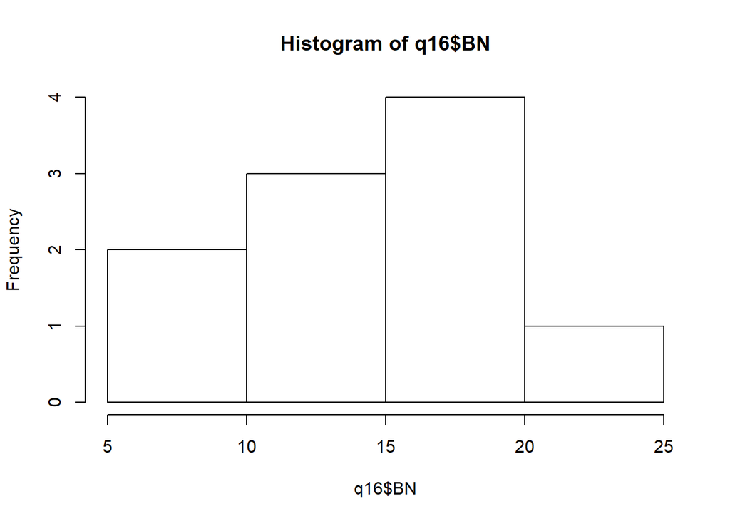

```r
#Histogram
hist(q16$BN)
```

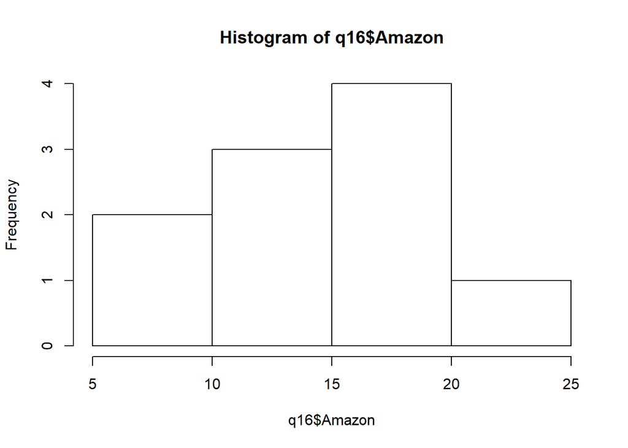

```r
hist(q16$Amazon)
```

```r
#p-value>0.05 -->failed to reject null hypothesis-normality condition met

#As both normality and variance conditions are met,
#proceed with paired t-test
t.test(q16$BN,q16$Amazon,mu=0,paired=TRUE)
```

```
##
##  Paired t-test
##
## data:  q16$BN and q16$Amazon
## t = 3.8173, df = 9, p-value = 0.004107
## alternative hypothesis: true difference in means is not equal to 0
## 95 percent confidence interval:
##  0.05540453 0.21659547
## sample estimates:
## mean of the differences
##                   0.136
```

```r
#As p-value<0.05,Reject null hypothesis
#There is significant difference between prices of both the sellers
```

The p-values<0.05, Reject null hypothesis At 5% significance, so we conclude that there is difference in prices across the two sellers

## Q17

All the necessary conditions are met for the goodness of fit test: 1.SRS -random sample of 100 observations-standardized 2.Contigency table consition met-intervals are mutually exclusive 3.Sample Size condition: expected counts>5

Hypotheses for the Chi-squared goodness of fit test:  
- $H_{0}$ : $ p_{1} =p_{2}=p_{3}=p_{4}=p_{5}$ - $H_{a}$ : At least one proportion differs from the expected normal distribution

```r
observed <- c(10,18,48,16,8)
#Computing Expected Probabililties
# p(z<=-1.5)
p1 <- pnorm(-1.5,0,1)
# p(-1.5< z <= -0.5) = p(z<= -0.5) - p(z<= -1.5)
p2 <- pnorm(-0.5,0,1)-pnorm(-1.5,0,1)
# p(-0.5< z <= 0.5) = p(z<=0.5) - p(z<=-0.5)
p3 <- pnorm(0.5,0,1) - pnorm(-0.5,0,1)
# p(0.5< z <=1.5) = p(z<=1.5) - p(z<=0.5)
p4 <- pnorm(1.5,0,1) - pnorm(0.5,0,1)
# p(z>1.5)= 1- p(z<=1.5)
p5 <- pnorm(1.5,0,1,lower.tail=FALSE)

expected <-c(p1,p2,p3,p4,p5)

#Performing chi-square goodness of fit test
chisq.test(x=observed,p=expected)
```

```
##
##  Chi-squared test for given probabilities
##
## data:  observed
## X-squared = 8.7104, df = 4, p-value = 0.06876
```

As the p-value>0.05 => Failed to Reject the null hypothesis As a result of which at 5% significance level, these counts are in agreement with the normal distribution

No,we can’t infer at the 5% significance level that the data were not drawn from a normal population But for significance level >=7%, we can reject the null hypothesis